# Situación Problema: Transporte en México

Author

Marissa Luna, Mariana León, Nubia Garcidueñas, Ximena Cantón.

**Abstract—** Este trabajo tiene como objetivo analizar y responder un conjunto de consultas asignadas mediante la construcción de redes bayesianas multinomiales. Para ello, se discretizaron variables continuas, se propusieron distintos grafos acíclicos dirigidos (DAGs) y se evaluaron sus relaciones de dependencia. Posteriormente, se aplicó el algoritmo de hill-climbing para identificar la estructura que mejor se ajusta a los datos. Los resultados muestran que la red obtenida permite responder de manera consistente las queries planteadas, confirmando la utilidad de este enfoque para modelar dependencias probabilísticas.

**Keywords—** Redes Bayesianas, Grafos Acíclicos Dirigidos, Inferencia Probabilística, Discretización de Variables, Hill-Climbing, Modelado Multinomial, Dependencias entre Variables

# Introducción

En 2017, el Instituto Nacional de Estadística y Geografía (INEGI) realizó la Encuesta Origen Destino en Hogares de la Zona Metropolitana del Valle de México (EOD 2017). Esta encuesta recopiló información detallada sobre los viajes diarios de los habitantes de la zona metropolitana, incluyendo origen y destino, motivo, duración, medio de transporte y horarios de desplazamiento. Dichos datos constituyen una fuente estadística clave para analizar la movilidad urbana y sirven como base para el presente trabajo.

Las redes bayesianas se han consolidado como una herramienta fundamental para el modelado de incertidumbre y la representación de relaciones de dependencia entre variables aleatorias. Estas estructuras han sido muy útiles en áreas como la bioinformática, el diagnóstico médico,clasificaciónde documentos, la inteligencia artificial y la toma de decisiones bajo incertidumbre [1].

El presente reto se centra en la construcción de una red bayesiana multinomial con el propósito de responder un conjunto de consultas previamente asignadas. La motivación de este trabajo se basa en la necesidad de contar con modelos que permitan inferir de manera eficiente la probabilidad de ciertos aspectos con respecto al transporte en México dado ciertas condiciones específicas en función de múltiples variables.

El problema abordado consiste en determinar qué estructura de red representa mejor las relaciones presentes en los datos y cómo esa estructura influye en la calidad de las respuestas a las consultas. Para ello, se comparan diferentes propuestas de grafos acíclicos dirigidos y se aplica un algoritmo de búsqueda que optimiza el ajuste de la red. Este trabajo resulta relevante al demostrar la importancia de las redes bayesianas como herramienta para la inferencia probabilística y el análisis de datos.

# Metodología

El enfoque metodológico en este caso, se basa en la construcción y análisis de redes bayesianas multinomiales para responder un conjunto de queries específicas asignadas. A continuación, se detallan los procedimientos, técnicas y herramientas empleadas:

## Preparación del entorno de trabajo

El desarrollo se realizó en un entorno de Python administrado con Anaconda, en combinación con R mediante la librería **reticulate**. Esto permitió integrar el preprocesamiento de datos en Python con la construcción y validación de redes bayesianas en R utilizando el paquete bnlearn.

El preprocesamiento consistió en integrar tablas de viajes y transportes a través del identificador de viaje, calcular la duración como diferencia entre la hora de inicio y fin del trayecto, y discretizar la variable continua de tiempo en dos categorías.

## Definición y construcción de variables

A partir de los conjuntos de datos de la Encuesta Origen Destino 2017 (EOD 2017), se seleccionaron y transformaron variables relevantes para representar los atributos de interés. Se definieron las siguientes variables discretas:

- **Estrato (E):** nivel de estrato social (4 niveles).
- **Semana (S):** si el viaje se realizó entre semana o fin de semana.
- **Origen (O):** lugar de inicio del viaje.
- **Propósito (P):** motivo principal del viaje.
- **Transporte (T):** medio de transporte utilizado.
- **Duración (D):** tiempo total de viaje (0 = viaje ≤ 60 minutos; 1 = viaje > 60 minutos).

## Propuesta de estructuras iniciales (DAGs)

Con las variables definidas se propusieron tres posibles grafos acíclicos dirigidos (DAGs) que representarán diferentes “hipótesis” sobre las relaciones de dependencia entre las variables. Estas estructuras se definieron manualmente con base en criterios de lógica y conocimiento previo sobre movilidad urbana.

## Estimación de parámetros

Para cada una de las estructuras propuestas se estimaron los parámetros de las redes bayesianas mediante el método de Máxima Verosimilitud (MLE), obteniendo así las distribuciones de probabilidad condicional correspondientes a cada nodo, bajo la fórmula que describe ese método:

$$L(\theta \mid x) = \prod_{i=1}^{n} f(x_i, \theta)$$

## Evaluación de las dependencias y ajuste del modelo

La significancia de las relaciones entre variables se evaluó mediante la medida de información mutua, siendo equivalente a la prueba de $G^{2}$, lo que permitió comparar la relevancia de los arcos en cada DAG, dada por:

$$G^{2} = 2 \sum_{t \in T} \sum_{e \in E} \sum_{k \in O \times R}
n_{tek} \log \left( \frac{n_{tek} \, n_{\cdot \cdot k}}{n_{t \cdot k} \, n_{\cdot e k}} \right)$$
Posteriormente, se calculó el Bayesian Information Criterion (BIC) para cada estructura, seleccionando aquella con mayor puntaje como el modelo de mejor ajuste.

## Optimización de la estructura mediante Hill-Climbing

Con el objetivo de mejorar la estructura, se aplicó el algoritmo de Hill-Climbing implementado en bnlearn, empleando el criterio BIC como función de puntuación. Este procedimiento permitió obtener de manera automática una DAG optimizada que refleja las relaciones más consistentes con los datos observados.

# Aplicación

Se llevó a cabo la implementación práctica de la metodología con base en la EOD 2017: construcción de variables, propuestas de DAG, ajuste de redes bayesianas, validación por BIC y *hill-climbing*, así como la resolución y discusión de cuatro *queries* específicas.

```r
#utilizamos ambiente de anaconda para cagar python
library(reticulate)
use_condaenv("base", required = TRUE)
```

## 1. Descripción de los datos y construcción de variables

✏️ **Construyan las variables que necesiten para dar respuesta a las queries asignadas. Si es necesario discreticen las variables continuas involucradas.**

Se parte de un set de viajes de la EOD 2017 (CDMX y zona metropolitana). Se integran tablas de viaje y transporte (vía `id_via`). Las variables utilizadas y su codificación (todas categóricas) son: Para la resolución de las queries se determinó el conjunto de variables [E, S, O, P, T, D], donde:

- **Estrato (E):**1 (bajo), 2 (medio bajo), 3 (medio alto), 4 (alto).
- **Semana (S):** 1 (Viaje entre semana), 2 (Viaje en domingo).
- **Origen (O):** 1 (Su Hogar), 2 (Escuela), 3 (Oficina)… 16 (Otro).
- **Propósito (P):** 1 (Ir al hogar), 2 (Ir al trabajo), 3 (Ir a estudiar)… 10 (Otro).
- **Transporte (T):** 1 (Automóvil), 2 (Colectivo/Micro), 3 (Taxi)… 20 (Otro).
- **Duración (D):** 0 (Menor o igual a 60 min), 1 (Más de 60 min).

```python
import pandas as pd
```

```python
viajes=pd.read_csv("data/eod_2017_csv/tviaje_eod2017/conjunto_de_datos/tviaje.csv")
transportes= pd.read_csv("data/eod_2017_csv/ttransporte_eod2017/conjunto_de_datos/ttransporte.csv")
```

```python
viajes.head()
```

```
   id_via  id_soc  p5_3  n_via  p5_6  ...  upm_dis  est_dis  tloc  sexo  edad
0    2936    1268     1      1     1  ...       87       40     1     2    26
1    2937    1268     1      2     3  ...       87       40     1     2    26
2    2938    1268     2      1     1  ...       87       40     1     2    26
3    2939    1268     2      2     7  ...       87       40     1     2    26
4    2940    1269     1      1     1  ...       87       40     1     2    22

[5 rows x 82 columns]
```

```python
transportes.head()
```

```
   id_tra  id_via  p5_3  n_via  p5_14  ...  upm_dis  est_dis  tloc  sexo  edad
0    3198    1810     2      2     14  ...       59       20     1     2    55
1    3199    1811     1      1      2  ...       59       20     1     2    38
2    3200    1811     1      1      5  ...       59       20     1     2    38
3    3201    1811     1      1     14  ...       59       20     1     2    38
4    3202    1811     1      1     14  ...       59       20     1     2    38

[5 rows x 18 columns]
```

```python
#unimos los df en id_via
df_joined = pd.merge(viajes, transportes, on = "id_via", how = "inner")
```

```python
#seleccionamos las columnas necesarias para represetar nuestras variables [E, S, O, P, T, D]
vars_= ["id_via","id_tra", "estrato_x","p5_3_x","p5_6","p5_9_1","p5_9_2","p5_10_1","p5_10_2","p5_13","p5_14","p5_14_16" ]
df_final= df_joined[vars_]
```

```python
#cambiamos nombre de las columnas
df_final.columns = ["id_via", "id_tra", "E", "S", "O","Hora1","Min1", "Hora2","Min2", "P", "T", "bicitaxi"]
```

```python
df_final.head()
```

```
   id_via  id_tra  E  S  O  Hora1  Min1  Hora2  Min2  P   T  bicitaxi
0    2936    5253  3  1  1      8     0      9     0  2  11         2
1    2936    5254  3  1  1      8     0      9     0  2  14         2
2    2937    5255  3  1  3     14     0     15    30  1  11         2
3    2937    5256  3  1  3     14     0     15    30  1  14         2
4    2938    5257  3  2  1     17     0     17     5  5  14         2
```

```python
#agregamos una columna de duración
#resultado de la resta de el comienzo y culminación del viaje
df_final["Duracion"]= (df_final["Hora2"]*60 + df_final["Min2"]) - (df_final["Hora1"]*60 + df_final["Min1"])
```

```python
#discretizamos la var. Duracion
#>60 = 1, <=60 = 0
df_final["D"]= (df_final["Duracion"] > 60).astype(int)
```

```python
#hacemos df nuevo con las variables finales
df_finalisimo = df_final[["E","S","O","P","T","D"]]
```

```python
df_finalisimo.head()
```

```
   E  S  O  P   T  D
0  3  1  1  2  11  0
1  3  1  1  2  14  0
2  3  1  3  1  11  1
3  3  1  3  1  14  1
4  3  2  1  5  14  0
```

```python
df_finalisimo.to_csv("data/dag.csv", index=False, encoding="utf-8")
```

## 2. DAGs propuestas

✏️ **Propongan al menos 3 diferentes DAGs que representen las relaciones de dependencia entre todas las variables de interés.**

```r
library(bnlearn)
```

```r
data = read.csv("data/dag.csv", stringsAsFactors = TRUE)
data[] <- lapply(data, factor) #columnas a factor
str(data)
```

```
'data.frame':   890748 obs. of  6 variables:
 $ E: Factor w/ 4 levels "1","2","3","4": 3 3 3 3 3 3 3 3 3 3 ...
 $ S: Factor w/ 2 levels "1","2": 1 1 1 1 2 2 1 1 1 1 ...
 $ O: Factor w/ 17 levels "1","2","3","4",..: 1 1 3 3 1 7 1 1 3 3 ...
 $ P: Factor w/ 11 levels "1","2","3","4",..: 2 2 1 1 5 1 2 2 1 1 ...
 $ T: Factor w/ 20 levels "1","2","3","4",..: 11 14 11 14 14 4 11 14 11 14 ...
 $ D: Factor w/ 2 levels "0","1": 1 1 2 2 1 1 1 1 2 2 ...
```

```r
head(data)
```

| E | S | O | P | T | D |
| --- | --- | --- | --- | --- | --- |
| 3 | 1 | 1 | 2 | 11 | 0 |
| 3 | 1 | 1 | 2 | 14 | 0 |
| 3 | 1 | 3 | 1 | 11 | 1 |
| 3 | 1 | 3 | 1 | 14 | 1 |
| 3 | 2 | 1 | 5 | 14 | 0 |
| 3 | 2 | 7 | 1 | 4 | 0 |

Se proponen tres estructuras causales como hipótesis iniciales:

**DAG 1**

El *modo* de transporte (`T`) y la *duración* (`D`) influyen en las condiciones del viaje junto con (`O`), (`P`) y (`E`). Hipótesis central: (`D`) depende directamente de (`T`).

```r
dag_1 = empty.graph(nodes = c("E", "S", "O", "P", "T", "D"))
```

```r
arc_set = matrix(c("E", "P",
                   "P", "S",
                   "E", "T",
                   "T", "D",
                   "O", "D"), byrow = TRUE, ncol = 2,
                 dimnames = list(NULL, c("from", "to")))
```

```r
arc_set
```

```
     from to
[1,] "E"  "P"
[2,] "P"  "S"
[3,] "E"  "T"
[4,] "T"  "D"
[5,] "O"  "D"
```

```r
arcs(dag_1) = arc_set
dag_1
```

```
  Random/Generated Bayesian network

  model:
   [E][O][P|E][T|E][S|P][D|O:T]
  nodes:                                 6
  arcs:                                  5
    undirected arcs:                     0
    directed arcs:                       5
  average markov blanket size:           2.00
  average neighbourhood size:            1.67
  average branching factor:              0.83

  generation algorithm:                  Empty
```

**DAG 2**

```r
dag_2 = empty.graph(nodes = c("E", "S", "O", "P", "T", "D"))
```

```r
arc_set = matrix(c("E", "P",
                   "S", "P",
                   "S", "O",
                   "P", "T",
                   "O", "T",
                   "T","D"), byrow = TRUE, ncol = 2,
                 dimnames = list(NULL, c("from", "to")))
```

```r
arc_set
```

```
     from to
[1,] "E"  "P"
[2,] "S"  "P"
[3,] "S"  "O"
[4,] "P"  "T"
[5,] "O"  "T"
[6,] "T"  "D"
```

```r
arcs(dag_2) = arc_set
dag_2
```

```
  Random/Generated Bayesian network

  model:
   [E][S][O|S][P|E:S][T|O:P][D|T]
  nodes:                                 6
  arcs:                                  6
    undirected arcs:                     0
    directed arcs:                       6
  average markov blanket size:           2.67
  average neighbourhood size:            2.00
  average branching factor:              1.00

  generation algorithm:                  Empty
```

**DAG 3**

(`T`) depende de (`E`) y (`D`) depende de (`T`); (`E`) depende de (`O`) y (`P`); (`S`) depende de (`P`). Esta estructura se utiliza explícitamente en los ejercicios de ajuste.

```r
dag_3 = empty.graph(nodes = c("E", "S", "O", "P", "T", "D"))
```

```r
arc_set = matrix(c("O", "E",
                   "P", "E",
                   "P", "S",
                   "E", "T",
                   "T", "D"), byrow = TRUE, ncol = 2,
                 dimnames = list(NULL, c("from", "to")))
```

```r
arc_set
```

```
     from to
[1,] "O"  "E"
[2,] "P"  "E"
[3,] "P"  "S"
[4,] "E"  "T"
[5,] "T"  "D"
```

```r
arcs(dag_3) = arc_set
```

```r
dag_3
```

```
  Random/Generated Bayesian network

  model:
   [O][P][E|O:P][S|P][T|E][D|T]
  nodes:                                 6
  arcs:                                  5
    undirected arcs:                     0
    directed arcs:                       5
  average markov blanket size:           2.00
  average neighbourhood size:            1.67
  average branching factor:              0.83

  generation algorithm:                  Empty
```

## 3. Modelación (redes bayesianas) y estimación

✏️ **Construyan una red bayesiana utilizando las DAGs que propusieron previamente.**

```r
bn_mle = bn.fit(dag_1, data = data, method = "mle")
```

```r
bn_mle = bn.fit(dag_2, data = data, method = "mle")
```

```r
bn_mle = bn.fit(dag_2, data = data, method = "mle")
```

## 4. Relaciones de dependencia

✏️ **Discutan la significancia de las relaciones de dependencia de sus DAGs.**

**DAG 1**

```r
arc.strength(dag_1, data = data, criterion = "mi")
```

| from | to | strength |
| --- | --- | --- |
| E | P | 0 |
| P | S | 0 |
| E | T | 0 |
| T | D | 0 |
| O | D | 0 |

**DAG 2**

```r
arc.strength(dag_2, data = data, criterion = "mi")
```

| from | to | strength |
| --- | --- | --- |
| E | P | 0 |
| S | P | 0 |
| S | O | 0 |
| P | T | 0 |
| O | T | 0 |
| T | D | 0 |

**DAG 3**

```r
arc.strength(dag_3, data = data, criterion = "mi")
```

| from | to | strength |
| --- | --- | --- |
| O | E | 0 |
| P | E | 0 |
| P | S | 0 |
| E | T | 0 |
| T | D | 0 |

En las tres DAGs todas las relaciones evaluadas muestran p-valores extremadamente pequeños (prácticamente 0), lo cual indica rechazo consistente de la hipótesis nula de independencia condicional para cada par de nodos conectados por un arco. Esto se debe a:

- *Especificación atenta de las DAGs:* las estructuras propuestas se diseñaron con base en conocimiento de dominio y en la codificación de las variables, por lo que las dependencias esperadas aparecen claramente en los datos.

## 5. Validación por BIC y selección del mejor ajuste

✏️ **¿Cuál es la red que mejor se ajuste a sus datos? ¿Por qué?**

Se compara el ajuste de las tres DAG mediante el Criterio de Información Bayesiano (BIC).

```r
bic1 <- score(dag_1, data = data, type = "bic")
bic2 <- score(dag_2, data = data, type = "bic")
bic3 <- score(dag_3, data = data, type = "bic")

cat("BIC DAG 1:", bic1, "\n")
```

```
BIC DAG 1: -6258404
```

```r
cat("BIC DAG 2:", bic2, "\n")
```

```
BIC DAG 2: -6238546
```

```r
cat("BIC DAG 3:", bic3, "\n")
```

```
BIC DAG 3: -6267011
```

El mayor (menos negativo) BIC corresponde a la *DAG 2*, por lo que es la que mejor se ajusta entre las propuestas.

## 6. Hill - climbing

✏️ **Utilicen el algoritmo hill-climbing para obtener la mejor estructura de la DAG para estos datos.**

Además de las DAG propuestas, se aprende una estructura automática con *hill-climbing* (score BIC).

```r
best_dag = hc(data) #Hill Climbing con BIC
```

```r
modelstring(best_dag)
```

```
[1] "[E][T|E][D|E:T][O|T:D][P|O:D][S|O:P:D]"
```

Esto implica, entre otros, que (`T`) depende de (`E`); (`D`) depende de (`E`) y (`T`); (`O`) depende de (`T`) y (`D`); (`P`) depende de (`O`) y (`D`); y (`S`) depende de (`O`), (`P`) y (`D`).

## 7. Relaciones de nueva DAG

✏️ **Discutan la pertinencia de las relaciones de esta nueva DAG.**

Se verifican las *arc strengths* por información mutua como chequeo de pertinencia.

```r
arc.strength(best_dag, data = data, criterion = "mi")
```

| from | to | strength |
| --- | --- | --- |
| O | P | 0 |
| T | D | 0 |
| P | S | 0 |
| O | S | 0 |
| E | T | 0 |
| D | P | 0 |
| D | O | 0 |
| T | O | 0 |
| E | D | 0 |
| D | S | 0 |

```r
#install.packages("BiocManager")
#BiocManager::install("Rgraphviz")
```

```r
library ("BiocManager")
```

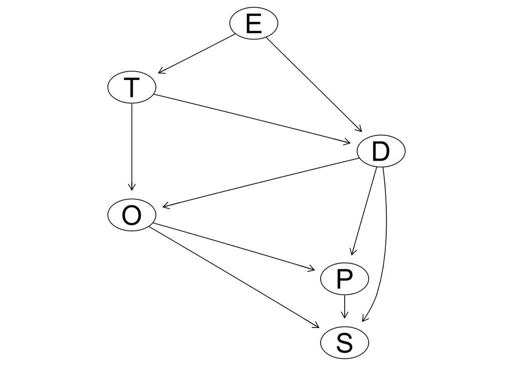

```r
graphviz.plot(best_dag, shape = "ellipse")
```

## 8. Queries

✏️ **Respondan las queries asignadas.**

A continuación se responden las cuatro consultas planteadas, usando (`cpquery`) sobre la red ajustada.

**Query 1** ¿Cuál es la probabilidad de que el viaje del hogar al trabajo dure más de 60 minutos si la persona usa transporte público?

```r
bn= bn.fit(best_dag, data= data)
cpquery(bn, event = (O=="1" & P=="2" & D=="1"), evidence = (T=="2"|T=="5"|T=="6"|T=="8"|T=="10"|T=="11"|T=="12"|T=="13"|T=="15"), n = 10^6)
```

```
[1] 0.1660922
```

```r
cpquery(bn, event = (E=="2"), evidence = (T=="1"), n = 10^6)
```

```
[1] 0.3770476
```

**Query 3** ¿Cuál es la probabilidad de que el estrato bajo, utilice transporte micro, metro, autobús?

```r
cpquery(bn, event = (T=="2"|T=="5"|T=="8"|T=="6"), evidence = (E=="1"), n = 10^6)
```

```
[1] 0.3880934
```

- *Interpretación:* La probabilidad de elección de transporte público entre estrato bajo ronda 38%, consistente con restricciones de costo y disponibilidad modal esperables.

```r
cpquery(bn, event = S == "1" & E == "2", evidence = list(T = "16"), method = "lw")
```

```
[1] 0.3926696
```

- *Interpretación:* Casi 4 de cada 10 viajes en bicitaxi ocurren entre semana y en estrato medio bajo, lo que puede asociarse a trayectos de primera/última milla en zonas específicas.

# Referencias

[1] D. Team, “Top 10 real-world bayesian network applications– know the importance!” https : / / data-flair . training / blogs /bayesian-network-applications/, n.d., recuperado el 30 de agosto de 2025.

[2] D. J. E. G. Guillén, “Redes bayesianas multinomiales,” file:///Users/ximenacanton/Downloads/Redes%20bayesianas%20multinomiales%20(5).html, 2025, archivo HTML. Recuperado el 30 de agosto de 2025.